# How can we get a better model?

This post was interesting because it begins to get at the limits of ChatGPT4, at least in so far as my prompting is concerned. Read on to see the failure modes of ChatGPT in this notebook.

```python
import pandas as pd
import numpy as np
import matplotlib as mpl
import matplotlib.pyplot as plt
import seaborn as sns
from matplotlib import rc

import tensorflow as tf
from tensorflow.keras.models import Sequential
from tensorflow.keras.layers import Dense

from sklearn.preprocessing import LabelEncoder
from sklearn.preprocessing import StandardScaler
from sklearn.model_selection import train_test_split

rc('text', usetex=True)
rc('text.latex', preamble=r'\usepackage{cmbright}')
rc('font', **{'family': 'sans-serif', 'sans-serif': ['Helvetica']})

%matplotlib inline

# This enables SVG graphics inline.
%config InlineBackend.figure_formats = {'png', 'retina'}

rc = {'lines.linewidth': 2,
      'axes.labelsize': 18,
      'axes.titlesize': 18,
      'axes.facecolor': 'DFDFE5'}
sns.set_context('notebook', rc=rc)
sns.set_style("dark")

mpl.rcParams['xtick.labelsize'] = 16
mpl.rcParams['ytick.labelsize'] = 16
mpl.rcParams['legend.fontsize'] = 14
```

[output not shown]

# Data

Reload the data we used previously:

```python
# chatgpt suggested:
url = "https://archive.ics.uci.edu/ml/machine-learning-databases/breast-cancer-wisconsin/wdbc.data"
data = pd.read_csv(url, header=None)

# The first column is an ID (we can ignore this), the second column is the label (M = malignant, B = benign),
# and the rest are features
labels = data.iloc[:, 1]
features = data.iloc[:, 2:]

scaler = StandardScaler()
features_scaled = scaler.fit_transform(features)
le = LabelEncoder()
labels_encoded = le.fit_transform(labels)
features_train, features_test, labels_train, labels_test =\
    train_test_split(features_scaled, labels_encoded,
                     test_size=0.2, random_state=42)
```

I gave chatGPT the minimal code from the previous post, and I asked it to help me write a hyperparameter tuning script. This is what it came up with:

```python
# chatgpt suggested the following, but is deprecated:
#from tensorflow.keras.wrappers.scikit_learn import KerasClassifier
# the right code is now:
from scikeras.wrappers import KerasClassifier

# from here, all chatgpt except choice of hyperparams, which is mine:
from sklearn.model_selection import GridSearchCV

def create_model(optimizer='adam', loss='binary_crossentropy'):
    m = Sequential()
    m.add(Dense(1, activation='sigmoid', input_shape=(features_train.shape[1],)))
    m.compile(loss=loss, optimizer=optimizer, metrics=['accuracy'])
    return m

# hyperparameters to tune over
param_grid = {
    'optimizer': ['SGD', 'RMSprop', 'Adam'],
    'epochs': [10, 20, 30],
    'batch_size': [10, 20, 30],
}

# do the grid search
model = KerasClassifier(model=create_model, verbose=0)
grid = GridSearchCV(estimator=model, param_grid=param_grid, cv=10)
grid_result = grid.fit(features_train, labels_train)

print(f"Best: {grid_result.best_score_} using {grid_result.best_params_}")
```

[output not shown]

Next, I asked it to fit the best model to the data, given the hyperparameter tuning results:

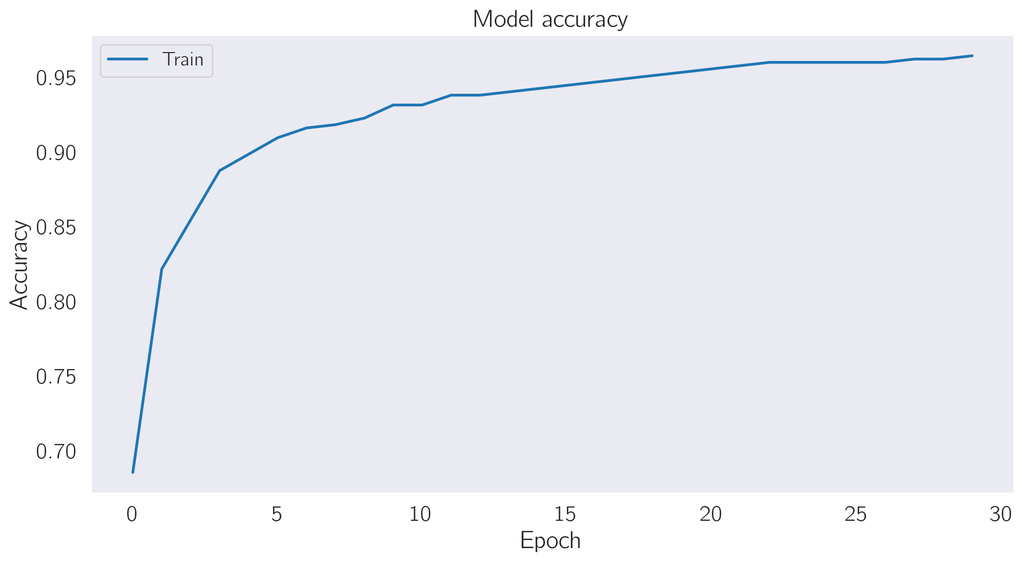

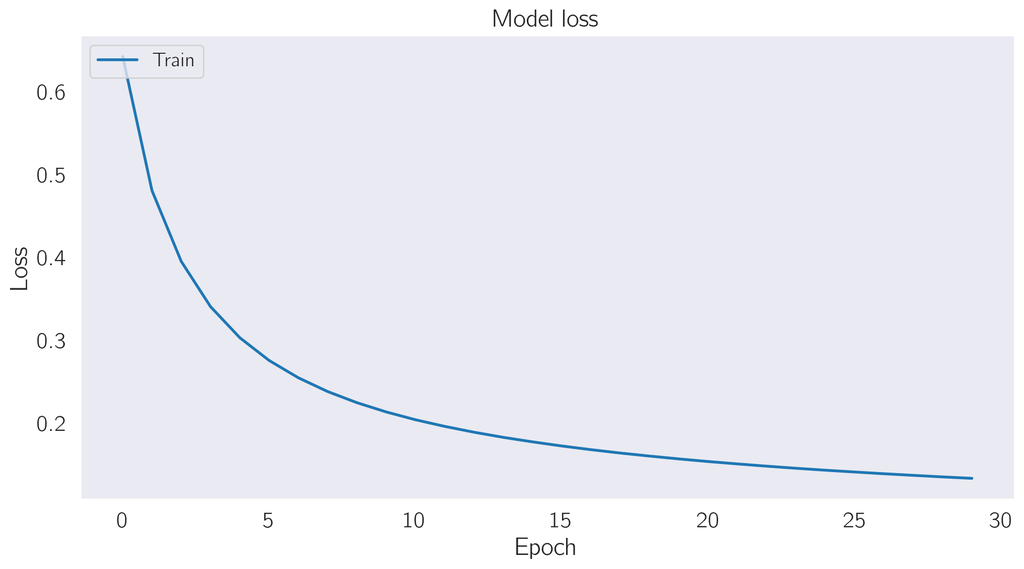

```python
# Extract the best parameters
best_params = grid_result.best_params_

# Train the model with the best parameters
model = create_model(best_params['optimizer'])
history = model.fit(features_train, labels_train,
                    epochs=best_params['epochs'],
                    batch_size=best_params['batch_size'],
                    verbose=0)

import matplotlib.pyplot as plt

# Plot training accuracy
plt.figure(figsize=(12, 6))
plt.plot(history.history['accuracy'])
plt.title('Model accuracy')
plt.ylabel('Accuracy')
plt.xlabel('Epoch')
plt.legend(['Train'], loc='upper left')
plt.show()

# Plot training loss
plt.figure(figsize=(12, 6))
plt.plot(history.history['loss'])
plt.title('Model loss')
plt.ylabel('Loss')
plt.xlabel('Epoch')
plt.legend(['Train'], loc='upper left')
plt.show()
```

```python
loss, accuracy = model.evaluate(features_test, labels_test, verbose=0)
print(f"Test loss: {loss}")
print(f"Test accuracy: {accuracy}")
```

```
Test loss: 0.10274569690227509
Test accuracy: 0.9824561476707458
```

Wow! We went from 94% accuracy to 98.2% accuracy, just by tuning the model a tiny bit! That is seriously cool--and ChatGPT did most of the work!

One of the things I was wondering about was whether we could also tune the choice of loss function and whether a multi-layer NN might outperform our very simple single-layer network. To study this, I modified the `param_grids` dictionary, and I re-wrote the `create_model` function (with Chat's help) to have a variable number of relu layers. Then, I asked Chat to hyperparameter optimize this new function....

```python
def create_model(optimizer='adam', loss='binary_crossentropy', num_layers=1):
    model = Sequential()

    # add relu layers
    for _ in range(num_layers):
        model.add(Dense(10, activation='relu'))

    # final layer for classification:
    model.add(Dense(1, activation='sigmoid'))
    # compile
    model.compile(loss=loss, optimizer=optimizer, metrics=['accuracy'])
    return model

param_grid = {
    'optimizer': ['SGD'],
    'loss': ['binary_crossentropy', 'hinge'],
    'epochs': [50, 100, 150],
    'batch_size': [10, 20],
    'num_layers': [1, 2]
}

model = KerasClassifier(model=create_model, verbose=0)

grid = GridSearchCV(estimator=model, param_grid=param_grid, cv=5)
grid_result = grid.fit(features_train, labels_train)

print(f"Best: {grid_result.best_score_} using {grid_result.best_params_}")
```

[output not shown]

[output cut: 100 more lines]

```
   1167             # in moving from the Keras wrappers
-> 1168             raise ValueError(
   1169                 f"Invalid parameter {param} for estimator {self.__name__}."
   1170                 "\nThis issue can likely be resolved by setting this parameter"
   1171                 f" in the {self.__name__} constructor:"
   1172                 f"\n`{self.__name__}({param}={value})`"
   1173                 "\nCheck the list of available parameters with"
   1174                 " `estimator.get_params().keys()`"
   1175             ) from None
   1176 return self

ValueError: Invalid parameter num_layers for estimator KerasClassifier.
This issue can likely be resolved by setting this parameter in the KerasClassifier constructor:
`KerasClassifier(num_layers=1)`
Check the list of available parameters with `estimator.get_params().keys()`
```

And it failed! So I gave the error message to ChatGPT and it was completely unable to fix the problem. To me, that is surprising--the error gives a solution that in fact works. However, ChatGPT was totally unablo to find a simple solution to this. Simply pasting the error message and trying to get it to fix the code (prompt: Please fix the code that is giving this error message) led to increasingly worse solutions.

Eventually, I remembered that zero-shot prompts that ask these LLMs to reason about their logic and enumerate steps frequently perform better. So, I prompted Chat to "Please reason about the error message by breaking it into pieces. Then suggest a solution based on this analysis of the error message", and it output the following (very hacky) code:

```python
from sklearn.model_selection import GridSearchCV

def create_model_func(num_layers=1):
    """A wrapper around `create_model`, which specifies how many layers `create_model` should have"""

    def create_model(optimizer='adam', loss='binary_crossentropy'):
        model = Sequential()

        # here chat made a mistake: when adding features, it's important to specify the
        # number of inputs into each layer

        # add layers. the architecture for this network goes from
        # M features --> 10 features with relu activation --> 10 .... --> 1 sigmoid node
        for _ in range(num_layers):
            if _ == 0:
                model.add(Dense(10, activation='relu', input_shape=(features_train.shape[1],)))
            else:
                model.add(Dense(10, activation='relu', input_shape=(10,)))
        if num_layers == 1:
            model.add(Dense(1, activation='sigmoid', input_shape=(features_train.shape[1],)))
        else:
            model.add(Dense(1, activation='sigmoid', input_shape=(10,)))
        model.compile(loss=loss, optimizer=optimizer, metrics=['accuracy'])
        return model

    #return a function with the number of layers pre-specified
    return create_model

param_grid = {
    'optimizer': ['SGD', 'Adam'],
    'loss': ['binary_crossentropy', 'hinge'],
    'epochs': [20, 40, 60],
    'batch_size': [10, 20, 30],
}

models = []
for num_layers in [1, 2]:
    model = KerasClassifier(model=create_model_func(num_layers), verbose=0)
    grid = GridSearchCV(estimator=model, param_grid=param_grid, cv=10)
    grid_result = grid.fit(features_train, labels_train)
    print(f"Best for {num_layers} layers: {grid_result.best_score_} using {grid_result.best_params_}")
    models.append(grid_result)
```

```
Best for 1 layers: 0.9824637681159419 using {'batch_size': 10, 'epochs': 40, 'loss': 'binary_crossentropy', 'optimizer': 'Adam'}
```

```
Best for 2 layers: 0.9780676328502416 using {'batch_size': 10, 'epochs': 60, 'loss': 'binary_crossentropy', 'optimizer': 'SGD'}
```

According to this code, it would be best to use a single layer!